# A_2.final

Study group 3

2022-11-04

#### Loading required packages

```r
pacman::p_load(glue,
       tidyr,
       data.table,
       moments,
       tidybayes,
       tibble,
       cowplot,
       viridis,
       brms,
       stringr,
       rstan,
       cmdstanr,
       magrittr,
       gridExtra,
       grid,
       lattice,
       ggplot2,
       ggridges,
       ellipse,
       Rmisc,
       dplyr,
       "rmarkdown",
       knitr)
pacman::p_load(tidyverse)
pacman::p_load(purr)
pacman::p_load(MCMCglmm)
pacman::p_load(readxl)
pacman::p_load(metafor)
```

# Assignment 2: meta-analysis

## Questions to be answered

1. Simulate data to setup the analysis and gain insight on the structure of the problem. Simulate one dataset of 100 studies (n of participants should follow a normal distribution with mean of 20, sd of 10, but no fewer than 10 participants), with a mean effect size of 0.4, average deviation by study of .4 and measurement error of .8. The data you get should have one row per study, with an effect size mean and standard error. Build a proper bayesian model to analyze the simulated data. Then simulate publication bias (only some of the studies you simulate are likely to be published, which?), the effect of publication bias on your estimates (re-run the model on published studies, assess the difference), and use at least one technique to assess publication bias. remember to use at least one plot to visualize your results. BONUS question: do a power/precision analysis.
2. What is the current evidence for distinctive vocal patterns in schizophrenia? Use the data from Parola et al (2020) - https://www.dropbox.com/s/0l9ur0gaabr80a8/Matrix_MetaAnalysis_Diagnosis_updated290719.xlsx?dl=0 - focusing on pitch variability (PITCH_F0SD). Describe the data available (studies, participants). Using the model from question 1 analyze the data, visualize and report the findings: population level effect size; how well studies reflect it; influential studies, publication bias. BONUS question: add the findings from https://www.medrxiv.org/content/10.1101/2022.04.03.22273354v2. BONUS question: assess the effect of task on the estimates (model comparison with baseline model)

# Sara

## Question 1

### Simulation

#### Outlining prior parameter provided by the assignment description

```r
mean_effect <- 0.4
effect_sd <- 0.4
meas_error <- 0.8
par_mean <- 20
par_sd <- 10
n <- 100
```

#### A simulation of participant data of multiple visits using the provided data

```r
set.seed(954)

sim_studies <-
  tibble(
    study_ID = seq(1:n),
    n_participants =
        round(rtnorm(n, mean=par_mean, sd=par_sd, lower=10))
    )


for (i in seq(nrow(sim_studies))){
    sim_studies$study_effect[i] <-
      rnorm(1,mean_effect,effect_sd)
    temp <-
      rnorm(sim_studies$n_participants[i],sim_studies$study_effect[i], meas_error)
    sim_studies$mean_effect_size[i] <-
      mean(temp)
    sim_studies$sd_effect[i] <-
      sd(temp)
    sim_studies$standard_error[i] <-
      sim_studies$sd_effect[i]/sqrt(sim_studies$n_participants[i])
  }
```

### Bayesian model

#### A Bayesian model illustrating potential effect sizes on individual participants

```r
model_study <- bf(mean_effect_size|se(standard_error) ~1 + (1|study_ID))
```

### Priors

#### Generating prior data simulations to model, using parameters provided in class

```r
get_prior(data = sim_studies, family = gaussian, model_study)
```

```
##                   prior     class      coef    group resp dpar nlpar lb ub
##  student_t(3, 0.3, 2.5) Intercept
##    student_t(3, 0, 2.5)        sd                                     0
##    student_t(3, 0, 2.5)        sd           study_ID                  0
##    student_t(3, 0, 2.5)        sd Intercept study_ID                  0
##        source
##       default
##       default
##  (vectorized)
##  (vectorized)
```

```r
priors <- c(
  prior(normal(0, 0.3), class=Intercept),
  prior(normal(0, 0.3), class=sd))
```

### Model

#### Modeling using sample_prior = ‘only’

```r
model_prior <- brm(
  model_study,
  data = sim_studies,
  prior = priors,
  family = gaussian,
  refresh=0,
  sample_prior = 'only',
  iter=10000,
  warmup = 1000,
  backend = "cmdstanr",
  threads = threading(2),
  chains = 2,
  cores = 2,
  control = list(
    adapt_delta = 0.99,
    max_treedepth = 20
)
)
```

```
## Running MCMC with 2 parallel chains, with 2 thread(s) per chain...
##
## Chain 2 finished in 4.3 seconds.
## Chain 1 finished in 4.4 seconds.
##
## Both chains finished successfully.
## Mean chain execution time: 4.4 seconds.
## Total execution time: 4.7 seconds.
```

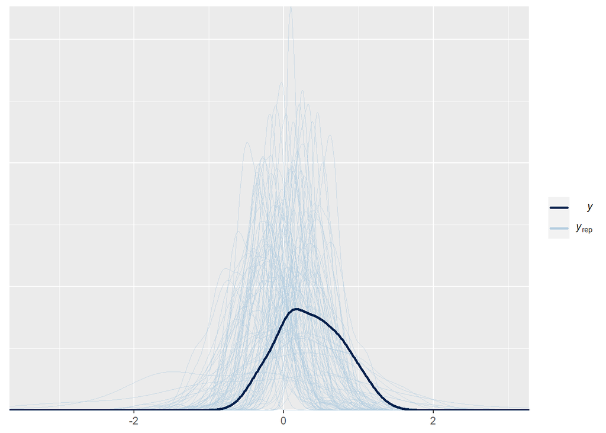

```r
pp_check(model_prior, ndraws=100)
```

## Manuela

### Fitting model

#### Modeling the sampled priors along with the simulation

```r
model_prior_fit <- brm(
  model_study,
  data = sim_studies,
  prior = priors,
  family = gaussian,
  refresh=0,
  sample_prior = TRUE,
  iter=10000,
  warmup = 1000,
  backend = "cmdstanr",
  threads = threading(2),
  chains = 2,
  cores = 2,
  control = list(
    adapt_delta = 0.99,
    max_treedepth = 20
)
)
```

```
## Running MCMC with 2 parallel chains, with 2 thread(s) per chain...
##
## Chain 2 finished in 9.2 seconds.
## Chain 1 finished in 24.8 seconds.
##
## Both chains finished successfully.
## Mean chain execution time: 17.0 seconds.
## Total execution time: 24.9 seconds.
```

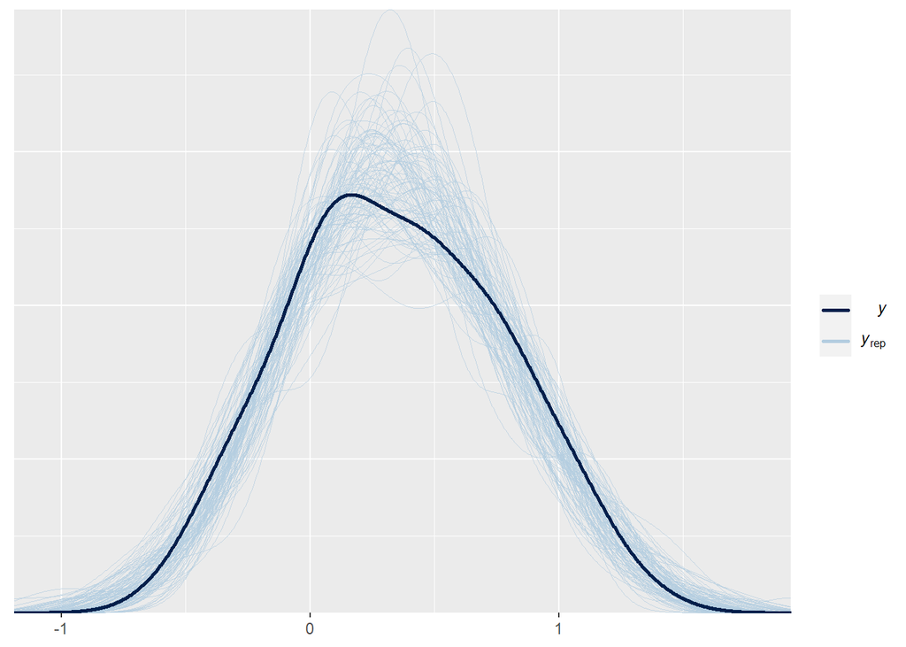

```r
pp_check(model_prior_fit, ndraws=100)
```

#### Plotting and visualizing

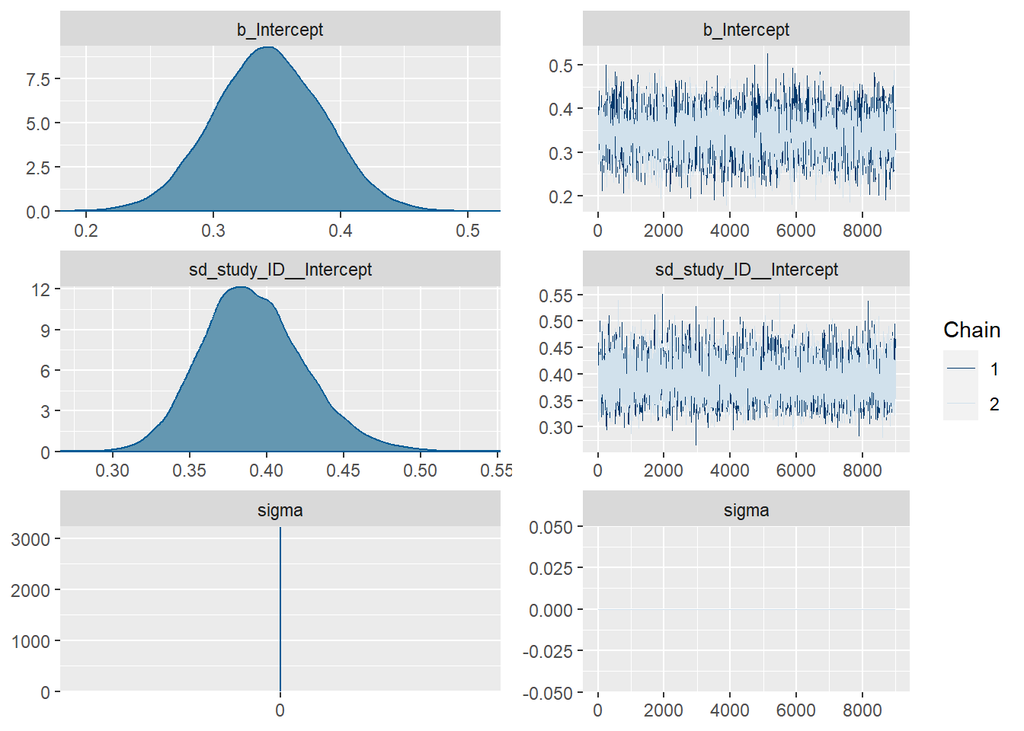

```r
plot(model_prior_fit)
```

```r
summary(model_prior_fit)
```

```
##  Family: gaussian
##   Links: mu = identity; sigma = identity
## Formula: mean_effect_size | se(standard_error) ~ 1 + (1 | study_ID)
##    Data: sim_studies (Number of observations: 100)
##   Draws: 2 chains, each with iter = 10000; warmup = 1000; thin = 1;
##          total post-warmup draws = 18000
##
## Group-Level Effects:
## ~study_ID (Number of levels: 100)
##               Estimate Est.Error l-95% CI u-95% CI Rhat Bulk_ESS Tail_ESS
## sd(Intercept)     0.39      0.03     0.33     0.46 1.00     4810     7853
##
## Population-Level Effects:
##           Estimate Est.Error l-95% CI u-95% CI Rhat Bulk_ESS Tail_ESS
## Intercept     0.34      0.04     0.26     0.43 1.00     3296     5775
##
## Family Specific Parameters:
##       Estimate Est.Error l-95% CI u-95% CI Rhat Bulk_ESS Tail_ESS
## sigma     0.00      0.00     0.00     0.00   NA       NA       NA
##
## Draws were sampled using sample(hmc). For each parameter, Bulk_ESS
## and Tail_ESS are effective sample size measures, and Rhat is the potential
## scale reduction factor on split chains (at convergence, Rhat = 1).
```

### Prior posterior update check

```r
model_posterior <- as_draws_df(model_prior_fit)

plot1 <- ggplot(model_posterior)+
  geom_histogram(aes(prior_Intercept), fill='red', color='black', alpha=0.3, bins=50)+
  geom_histogram(aes(Intercept), fill='green', color='black', alpha=0.3, bins=50)+
  theme_classic()+
  ggtitle('prior-posterior update check on intercept')+
  xlab('intercept')
plot2 <- ggplot(model_posterior)+
  geom_histogram(aes(prior_sd_study_ID), fill='red', color='black', alpha=0.3, bins=50)+
  geom_histogram(aes(sd_study_ID__Intercept), fill='green', color='black', alpha=0.3, bins=50)+
  theme_classic()+
  ggtitle('prior-posterior update check on standard deviation of the intercept')+
  xlab('intercept')
grid.arrange(plot1, plot2)
```

[output not shown]

### Simulation of publication bias, the effect of publication bias on our estimate and asses the publication bias (remember to visualize our results)

#### Simulating the effect size of the publication factors and filtering data for only published studies

```r
set.seed(843)

for (i in seq(nrow(sim_studies))){
  sim_studies$published[i] <-
    ifelse(abs(
      sim_studies$mean_effect_size[i])-(2*sim_studies$standard_error[i])>0
      & sim_studies$mean_effect_size[i]>0,
      rbinom(1,1,0.9), rbinom(1,1,0.1))}

sim_studies <- sim_studies %>%
  mutate(published=as.factor(published))

pub_sim_studies <- dplyr::filter(sim_studies, published==1)
```

```r
pub_model_prior_fit <- brm(
  model_study,
  data = pub_sim_studies,
  prior = priors,
  family = gaussian,
  refresh=0,
  sample_prior = TRUE,
  iter=10000,
  warmup = 1000,
  backend = "cmdstanr",
  threads = threading(2),
  chains = 2,
  cores = 2,
  control = list(
    adapt_delta = 0.99,
    max_treedepth = 20
)
)
```

```
## Running MCMC with 2 parallel chains, with 2 thread(s) per chain...
##
## Chain 2 finished in 6.1 seconds.
## Chain 1 finished in 8.6 seconds.
##
## Both chains finished successfully.
## Mean chain execution time: 7.3 seconds.
## Total execution time: 8.7 seconds.
```

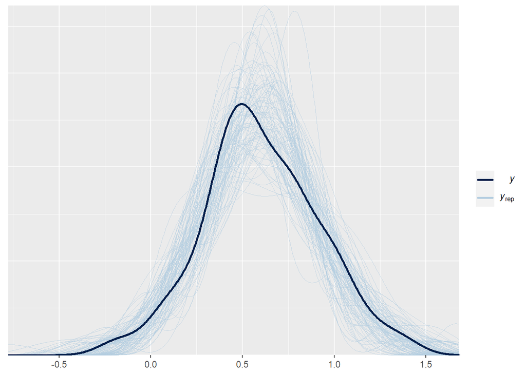

```r
pp_check(pub_model_prior_fit, ndraws=100)
```

## Ditlev

#### Potting and assesing and transforming the brmsfit to draws

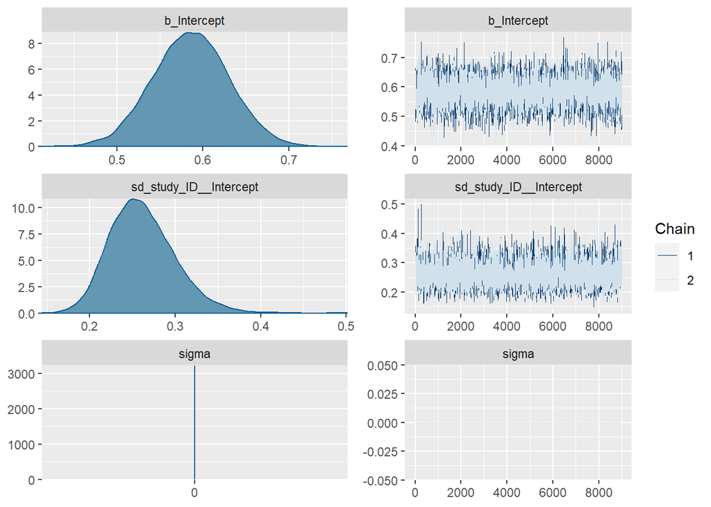

```r
plot(pub_model_prior_fit)
```

```r
summary(pub_model_prior_fit)
```

```
##  Family: gaussian
##   Links: mu = identity; sigma = identity
## Formula: mean_effect_size | se(standard_error) ~ 1 + (1 | study_ID)
##    Data: pub_sim_studies (Number of observations: 48)
##   Draws: 2 chains, each with iter = 10000; warmup = 1000; thin = 1;
##          total post-warmup draws = 18000
##
## Group-Level Effects:
## ~study_ID (Number of levels: 48)
##               Estimate Est.Error l-95% CI u-95% CI Rhat Bulk_ESS Tail_ESS
## sd(Intercept)     0.26      0.04     0.20     0.34 1.00     6185     9664
##
## Population-Level Effects:
##           Estimate Est.Error l-95% CI u-95% CI Rhat Bulk_ESS Tail_ESS
## Intercept     0.59      0.04     0.50     0.67 1.00     5530     9317
##
## Family Specific Parameters:
##       Estimate Est.Error l-95% CI u-95% CI Rhat Bulk_ESS Tail_ESS
## sigma     0.00      0.00     0.00     0.00   NA       NA       NA
##
## Draws were sampled using sample(hmc). For each parameter, Bulk_ESS
## and Tail_ESS are effective sample size measures, and Rhat is the potential
## scale reduction factor on split chains (at convergence, Rhat = 1).
```

```r
pub_posterior <- as_draws_df(pub_model_prior_fit)
```

```r
pub_plot1 <- ggplot(pub_posterior)+
  geom_histogram(aes(prior_Intercept), fill='red', color='black', alpha=0.3, bins=50)+
  geom_histogram(aes(Intercept), fill='green', color='black', alpha=0.3, bins=50)+
  theme_classic()+
  ggtitle('prior-posterior update check on intercept (published)')+
  xlab('intercept')
pub_plot2 <- ggplot(pub_posterior)+
  geom_histogram(aes(prior_sd_study_ID), fill='red', color='black', alpha=0.3, bins=50)+
  geom_histogram(aes(sd_study_ID__Intercept), fill='green', color='black', alpha=0.3, bins=50)+
  theme_classic()+
  ggtitle('prior-posterior update check on standard deviation of the intercept (published)')+
  xlab('sd')
grid.arrange(pub_plot1, pub_plot2)
```

[output not shown]

#### Plotting “effect size with and without the un-published studis” and “tandard deviation of the effect size with and without the un-published studis”

[figure not shown]

```r
plot3 <- ggplot()+
  geom_histogram(aes(pub_posterior$Intercept), fill='red', color='black', alpha=0.3, bins=50)+
  geom_histogram(aes(model_posterior$Intercept), fill='green', color='black', alpha=0.3, bins=50)+
  theme_classic()+
  ggtitle('effect size with and without the un-published studis')+
  xlab('red=only published, green=with un-published')
plot4 <- ggplot()+
  geom_histogram(aes(pub_posterior$sd_study_ID__Intercept), fill='red', color='black', alpha=0.3, bins=50)+
  geom_histogram(aes(model_posterior$sd_study_ID__Intercept), fill='green', color='black', alpha=0.3, bins=50)+
  theme_classic()+
  ggtitle('standard deviation of the effect size with and without the un-published studis')+
  xlab('red=only published, green=with un-published')
grid.arrange(plot3, plot4)
```

## Question 2

#### Loading the data

```r
matrix_ma <- read_excel("/Users/patrikmolnar/Desktop/Cognitive Science/Semester 3/Methods3/Matrix_MetaAnalysis.xlsx")
```

```
## Error: `path` does not exist: '/Users/patrikmolnar/Desktop/Cognitive Science/Semester 3/Methods3/Matrix_MetaAnalysis.xlsx'
```

### Describing the data

#### Filtering out NA & NR for SZ

```r
matrix_ma_filter_for_analysis <- matrix_ma %>%
  dplyr::filter(AGE_M_SZ!="NR") %>%
  dplyr::filter(AGE_M_SZ!="NA")
```

```
## Error in dplyr::filter(., AGE_M_SZ != "NR"): object 'matrix_ma' not found
```

```r
matrix_ma_filter_for_analysis <- matrix_ma_filter_for_analysis %>%
  dplyr::filter(AGE_SD_SZ!="NR") %>%
  dplyr::filter(AGE_SD_SZ!="NA")
```

```
## Error in dplyr::filter(., AGE_SD_SZ != "NR"): object 'matrix_ma_filter_for_analysis' not found
```

```r
matrix_ma_filter_for_analysis <- matrix_ma_filter_for_analysis %>%
  dplyr::filter(MALE_SZ!="NR") %>%
  dplyr::filter(MALE_SZ!="NA")
```

```
## Error in dplyr::filter(., MALE_SZ != "NR"): object 'matrix_ma_filter_for_analysis' not found
```

```r
matrix_ma_filter_for_analysis <- matrix_ma_filter_for_analysis %>%
  dplyr::filter(FEMALE_SZ!="NR") %>%
  dplyr::filter(FEMALE_SZ!="NA")
```

```
## Error in dplyr::filter(., FEMALE_SZ != "NR"): object 'matrix_ma_filter_for_analysis' not found
```

#### Filtering out NA & NR for HC

```r
matrix_ma_filter_for_analysis <- matrix_ma_filter_for_analysis %>%
  dplyr::filter(AGE_M_HC!="NR") %>%
  dplyr::filter(AGE_M_HC!="NA")
```

```
## Error in dplyr::filter(., AGE_M_HC != "NR"): object 'matrix_ma_filter_for_analysis' not found
```

```r
matrix_ma_filter_for_analysis <- matrix_ma_filter_for_analysis %>%
  dplyr::filter(AGE_SD_HC!="NR") %>%
  dplyr::filter(AGE_SD_HC!="NA")
```

```
## Error in dplyr::filter(., AGE_SD_HC != "NR"): object 'matrix_ma_filter_for_analysis' not found
```

```r
matrix_ma_filter_for_analysis <- matrix_ma_filter_for_analysis %>%
  dplyr::filter(MALE_HC!="NR") %>%
  dplyr::filter(MALE_HC!="NA")
```

```
## Error in dplyr::filter(., MALE_HC != "NR"): object 'matrix_ma_filter_for_analysis' not found
```

```r
matrix_ma_filter_for_analysis <- matrix_ma_filter_for_analysis %>%
  dplyr::filter(FEMALE_HC!="NR") %>%
  dplyr::filter(FEMALE_HC!="NA")
```

```
## Error in dplyr::filter(., FEMALE_HC != "NR"): object 'matrix_ma_filter_for_analysis' not found
```

#### Making the variables numeric for SZ

```r
matrix_ma_filter_for_analysis$AGE_M_SZ <- as.numeric(matrix_ma_filter_for_analysis$AGE_M_SZ)
```

```
## Error in eval(expr, envir, enclos): object 'matrix_ma_filter_for_analysis' not found
```

```r
matrix_ma_filter_for_analysis$AGE_SD_SZ <- as.numeric(matrix_ma_filter_for_analysis$AGE_SD_SZ)
```

```
## Error in eval(expr, envir, enclos): object 'matrix_ma_filter_for_analysis' not found
```

```r
matrix_ma_filter_for_analysis$MALE_SZ <- as.numeric(matrix_ma_filter_for_analysis$MALE_SZ)
```

```
## Error in eval(expr, envir, enclos): object 'matrix_ma_filter_for_analysis' not found
```

```r
matrix_ma_filter_for_analysis$FEMALE_SZ <- as.numeric(matrix_ma_filter_for_analysis$FEMALE_SZ)
```

```
## Error in eval(expr, envir, enclos): object 'matrix_ma_filter_for_analysis' not found
```

#### Making the variables numeric for HC

```r
matrix_ma_filter_for_analysis$AGE_M_HC <- as.numeric(matrix_ma_filter_for_analysis$AGE_M_HC)
```

```
## Error in eval(expr, envir, enclos): object 'matrix_ma_filter_for_analysis' not found
```

```r
matrix_ma_filter_for_analysis$AGE_SD_HC <- as.numeric(matrix_ma_filter_for_analysis$AGE_SD_HC)
```

```
## Error in eval(expr, envir, enclos): object 'matrix_ma_filter_for_analysis' not found
```

```r
matrix_ma_filter_for_analysis$MALE_HC <- as.numeric(matrix_ma_filter_for_analysis$MALE_HC)
```

```
## Error in eval(expr, envir, enclos): object 'matrix_ma_filter_for_analysis' not found
```

```r
matrix_ma_filter_for_analysis$FEMALE_HC <- as.numeric(matrix_ma_filter_for_analysis$FEMALE_HC)
```

```
## Error in eval(expr, envir, enclos): object 'matrix_ma_filter_for_analysis' not found
```

## Patrik

#### Making both tibbles in order to combine them and make them easier for the eye

```r
a <- tibble(diagnosis = "SZ",
         mean_sample_size=mean(matrix_ma_filter_for_analysis$SAMPLE_SIZE_SZ),
         mean_numer_of_males=mean(matrix_ma_filter_for_analysis$MALE_SZ),
         mean_number_of_females=mean(matrix_ma_filter_for_analysis$FEMALE_SZ),
         mean_age=mean(matrix_ma_filter_for_analysis$AGE_M_SZ),
         mean_sd_age=mean(matrix_ma_filter_for_analysis$AGE_SD_SZ)
         )
```

```
## Error in h(simpleError(msg, call)): error in evaluating the argument 'x' in selecting a method for function 'mean': object 'matrix_ma_filter_for_analysis' not found
```

```r
b <- tibble(diagnosis = "HC",
         mean_sample_size=mean(matrix_ma_filter_for_analysis$SAMPLE_SIZE_HC),
         mean_numer_of_males=mean(matrix_ma_filter_for_analysis$MALE_HC),
         mean_number_of_females=mean(matrix_ma_filter_for_analysis$FEMALE_HC),
         mean_age=mean(matrix_ma_filter_for_analysis$AGE_M_HC),
         mean_sd_age=mean(matrix_ma_filter_for_analysis$AGE_SD_HC)
         )
```

```
## Error in h(simpleError(msg, call)): error in evaluating the argument 'x' in selecting a method for function 'mean': object 'matrix_ma_filter_for_analysis' not found
```

#### Binding the rows together

```r
Demographic_overview <- bind_rows(a,b)
```

```
## Error in list2(...): object 'a' not found
```

#### Showing the tibble

```r
Demographic_overview
```

```
## Error in eval(expr, envir, enclos): object 'Demographic_overview' not found
```

#### Selceting the relevant variables

```r
matrix_pitch <- matrix_ma %>%
  select('StudyID','Article','SAMPLE_SIZE_SZ','SAMPLE_SIZE_HC', 'PITCH_F0SD_HC_M','PITCH_F0SD_HC_SD','PITCH_F0SD_SZ_M','PITCH_F0SD_SZ_SD')
```

```
## Error in select(., "StudyID", "Article", "SAMPLE_SIZE_SZ", "SAMPLE_SIZE_HC", : object 'matrix_ma' not found
```

#### Filtering out the NA

```r
matrix_pitch <- matrix_pitch %>%
  na.omit()
```

```
## Error in na.omit(.): object 'matrix_pitch' not found
```

#### Merging diagnosis into one variable

```r
matrix_pitch <- matrix_pitch %>%
  mutate(sample_size=(SAMPLE_SIZE_SZ+SAMPLE_SIZE_HC))
```

```
## Error in mutate(., sample_size = (SAMPLE_SIZE_SZ + SAMPLE_SIZE_HC)): object 'matrix_pitch' not found
```

#### Creating IDs for the studies

```r
matrix_pitch <- matrix_pitch %>%
  mutate(StudyID=as.factor(StudyID))
```

```
## Error in mutate(., StudyID = as.factor(StudyID)): object 'matrix_pitch' not found
```

```r
matrix_pitch <- matrix_pitch %>%
  mutate(StudyID=as.numeric(StudyID))
```

```
## Error in mutate(., StudyID = as.numeric(StudyID)): object 'matrix_pitch' not found
```

```r
matrix_pitch <- matrix_pitch %>%
  mutate(StudyID=as.factor(StudyID))
```

```
## Error in mutate(., StudyID = as.factor(StudyID)): object 'matrix_pitch' not found
```

#### Getting normalized results

```r
matrix_pitch <- escalc('SMD',
n1i=SAMPLE_SIZE_HC,
n2i=SAMPLE_SIZE_SZ,
m1i = PITCH_F0SD_HC_M,
m2i=PITCH_F0SD_SZ_M,
sd1i = PITCH_F0SD_HC_SD,
sd2i = PITCH_F0SD_SZ_SD,
data = matrix_pitch)
```

```
## Error in escalc("SMD", n1i = SAMPLE_SIZE_HC, n2i = SAMPLE_SIZE_SZ, m1i = PITCH_F0SD_HC_M, : object 'matrix_pitch' not found
```

```r
matrix_pitch <- matrix_pitch %>%
  rename(effect_size=yi)
```

```
## Error in rename(., effect_size = yi): object 'matrix_pitch' not found
```

#### Creating a loop to calculate sd effect size and se

```r
for (i in seq(nrow(matrix_pitch))){
  matrix_pitch$sd_effect[i] <- sqrt((sum((matrix_pitch$effect_size[i] - mean(matrix_pitch$effect_size))^2))/length(matrix_pitch))
  matrix_pitch$standard_error[i] <- matrix_pitch$sd_effect[i]/sqrt(matrix_pitch$sample_size)
}
```

```
## Error in nrow(matrix_pitch): object 'matrix_pitch' not found
```

#### Setting model

```r
model_matrix <- bf(effect_size|se(standard_error) ~1 + (1|StudyID))
```

#### Getting priors

```r
get_prior(data = matrix_pitch, family = gaussian, model_matrix)
```

```
## Error in get_knots(data): object 'matrix_pitch' not found
```

#### Setting priors

```r
matrix_priors <- c(
  prior(normal( .3, 2.5), class=Intercept),
  prior(normal( 0, 2.5), class=sd))
```

#### Priors

```r
matrix_prior_fit <- brm(
  model_matrix,
  data = matrix_pitch,
  prior = matrix_priors,
  family = gaussian,
  refresh=0,
  sample_prior = 'only',
  iter=10000,
  warmup = 1000,
  backend = "cmdstanr",
  threads = threading(2),
  chains = 2,
  cores = 2,
  control = list(
    adapt_delta = 0.99,
    max_treedepth = 20
)
)
```

```
## Error in get_knots(data): object 'matrix_pitch' not found
```

## Bryan

#### Assesing results

```r
matrix_prior_fit
```

```
## Error in eval(expr, envir, enclos): object 'matrix_prior_fit' not found
```

#### PP check

```r
pp_check(matrix_prior_fit, ndraws=100)
```

```
## Error in pp_check(matrix_prior_fit, ndraws = 100): object 'matrix_prior_fit' not found
```

```r
matrix_fit <- brm(
  model_matrix,
  data = matrix_pitch,
  prior = matrix_priors,
  family = gaussian,
  refresh=0,
  sample_prior = 'only',
  iter=10000,
  warmup = 1000,
  backend = "cmdstanr",
  threads = threading(2),
  chains = 2,
  cores = 2,
  control = list(
    adapt_delta = 0.99,
    max_treedepth = 20
)
)
```

```
## Error in get_knots(data): object 'matrix_pitch' not found
```

#### PP check

```r
pp_check(matrix_fit)
```

```
## Error in pp_check(matrix_fit): object 'matrix_fit' not found
```

#### Plotting and assesing the results

```r
plot(matrix_fit)
```

```
## Error in h(simpleError(msg, call)): error in evaluating the argument 'x' in selecting a method for function 'plot': object 'matrix_fit' not found
```

```r
summary(matrix_fit)
```

```
## Error in h(simpleError(msg, call)): error in evaluating the argument 'object' in selecting a method for function 'summary': object 'matrix_fit' not found
```

#### Visualizing and assesing intercepts

```r
matrix_posterior <- as_draws_df(matrix_fit)
```

```
## Error in as_draws_df(matrix_fit): object 'matrix_fit' not found
```

```r
plot1 <- ggplot(matrix_posterior)+
  geom_histogram(aes(model_posterior$prior_Intercept), fill='red', color='black', alpha=0.3, bins=50)+
  geom_histogram(aes(Intercept), fill='green', color='black', alpha=0.3, bins=50)+
  theme_classic()+
  ggtitle('prior-posterior update check on intercept')+
  xlab('intercept')
```

```
## Error in ggplot(matrix_posterior): object 'matrix_posterior' not found
```

#### Visualizing standard deviation

```r
plot2 <- ggplot(matrix_posterior)+
  geom_histogram(aes(model_posterior$prior_sd_study_ID), fill='red', color='black', alpha=0.3, bins=50)+
  geom_histogram(aes(model_posterior$sd_study_ID__Intercept), fill='green', color='black', alpha=0.3, bins=50)+
  theme_classic()+
  ggtitle('prior-posterior update check on standard deviation of the intercept')+
  xlab('intercept')
```

```
## Error in ggplot(matrix_posterior): object 'matrix_posterior' not found
```

#### Printing plots

```r
plot1
```

[output not shown]

[figure not shown]

```r
plot2
```

```r
grid.arrange(plot1, plot2)
```

[output not shown]

### Influencial studies

#### Excluding the Cohen et al. (2014) by indexing

```r
excluded_matrix <- matrix_pitch %>%
  dplyr::filter(StudyID!=6)
```

```
## Error in dplyr::filter(., StudyID != 6): object 'matrix_pitch' not found
```

#### Running the model

```r
exclude_matrix_fit <- brm(
  model_matrix,
  data = excluded_matrix,
  prior = matrix_priors,
  family = gaussian,
  refresh=0,
  sample_prior = 'only',
  iter=10000,
  warmup = 1000,
  backend = "cmdstanr",
  threads = threading(2),
  chains = 2,
  cores = 2,
  control = list(
    adapt_delta = 0.99,
    max_treedepth = 20
)
)
```

```
## Error in get_knots(data): object 'excluded_matrix' not found
```

#### Visualizing and plotting

```r
pp_check(exclude_matrix_fit)
```

```
## Error in pp_check(exclude_matrix_fit): object 'exclude_matrix_fit' not found
```

```r
plot(exclude_matrix_fit)
```

```
## Error in h(simpleError(msg, call)): error in evaluating the argument 'x' in selecting a method for function 'plot': object 'exclude_matrix_fit' not found
```

```r
summary(exclude_matrix_fit)
```

```
## Error in h(simpleError(msg, call)): error in evaluating the argument 'object' in selecting a method for function 'summary': object 'exclude_matrix_fit' not found
```